# An Example of Regular Data Analysis

```r
library(DGP4LCF)
```

In this example, we apply the BSFA-DGP model to simulated data, which were generated under the scenario where latent factors were correlated and had small variability (scenario CS) in the paper. We show how to use different functions within the package to conduct a full data analysis.

The object ‘sim_fcs_truth’ saves the simulated data. Before using functions within this package for analysis, the user has to prepare the initial values for latent factor scores $y$, regression coefficients of factor loadings $a$, binary variables of factor loadings $z$ and also the variance for residuals $\phi^2$. One possible way to obtain initial values is to use the [BFRM program](http://www2.stat.duke.edu/~mw/mwsoftware/BFRM/examples.html) to conduct a simple Bayesian Sparse Factor Analysis for independent data. We have already saved initial values for use in ‘sim_fcs_init’. Note that to save the time for knitting rmarkdown, we have also saved other results of this simulated data in the object named ‘sim_fcs_results_regular_8’, and users should be able to reproduce all results following the instructions in this vignette.

First, we use the function ‘mcem_parameters_setup’ to generate R objects storing parameters in the model that are needed in the following Monte Carlo Expectation Maximization (MCEM) algorithm.

```r
# for reproducibility purpose
set.seed(456)

# create objects required in the function input
q<- 8
n<- 17

obs_time_num<- rep(q, times = n)
obs_time_index<- list()
a_person<- list()
col_person_index<- list()
observed_x_train_regular_8<- list()

for (person_index in 1:n){
  obs_time_index[[person_index]]<- (1:q)
  a_person[[person_index]]<- sim_fcs_truth$a_full[(1:q)]
  col_person_index[[person_index]]<- ((person_index-1)*q + 1):(person_index*q)
  observed_x_train_regular_8[[person_index]]<- sim_fcs_truth$observed_x_train[,,person_index]
}

mcem_parameter_setup_result<-
  mcem_parameter_setup(p = 100, k = 4, n = 17, q = 8,
                       obs_time_num = obs_time_num,
                       obs_time_index = obs_time_index,
                       a_person = a_person,
                       col_person_index = col_person_index,
                       y_init = sim_fcs_init$y_init,
                       a_init = sim_fcs_init$a_init_2,
                       z_init = sim_fcs_init$z_init_2,
                       phi_init = sim_fcs_init$phi_init,
                       a_full = sim_fcs_truth$a_full,
                       x = observed_x_train_regular_8,
                       train_index = (1:8))
```

Next, these generated R objects, along with other model setups created by the user, can be input to the function ‘mcem_algorithm’ to find the Maximum Likelihood Estimate (MLE) of Dependent Gaussian Process (DGP) parameters. Here, we choose a model with an intercept term denoting subject-gene mean.

```r
mcem_algorithm_result<-
  mcem_algorithm(ind_x = TRUE,
                 x = observed_x_train_regular_8,
                 mcem_parameter_setup_result = mcem_parameter_setup_result)
```

The function ‘mcem_cov_plot’ visualizes the updating process of cross-correlations. The true cross-correlation is also displayed for comparison.

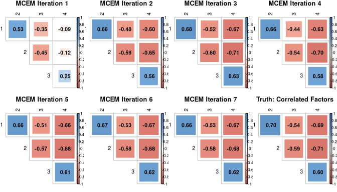

```r
old_par <- par(no.readonly = TRUE)

par(mfrow = c(2,4))
for (em_index in 1:sim_fcs_results_regular_8$mcem_algorithm_result$index_used){
  mcem_cov_plot(sim_fcs_results_regular_8$mcem_algorithm_result$sigmay_record[em_index,,], k = 4, q = 8, title = paste0("MCEM Iteration ", em_index))
}

mcem_cov_plot(sim_fcs_truth$gp_sigmay_truth, k = 4, q = 10, title = "Truth: Correlated Factors")
```

```r
par(old_par)
```

Under the MLE of DGP parameters, we run the final Gibbs sampler for the posterior summary of other parameters in the model, and also of the predicted gene expression. We run multiple chains in parallel, and use the function ‘gibbs_after_mcem_diff_initials’ to generate different initial values for different chains.

```r
gibbs_after_mcem_diff_initials_result<-
  gibbs_after_mcem_diff_initials(ind_x = TRUE,
                                 tot_chain = 5,
                                 mcem_parameter_setup_result = mcem_parameter_setup_result,
                                 mcem_algorithm_result = mcem_algorithm_result)
```

After initialization, we can run multiple chains, and posterior samples (after burnin and thinning, as designated by the user) will be saved as csv files to the specified location. One csv file contains samples of one parameter, and each row within the csv file contains samples from one Gibbs iteration.

```r
tot_chain<- 5

for (chain_index in 1:tot_chain){

  gibbs_after_mcem_algorithm(chain_index = chain_index,
                                            mc_num = 10000,
                                            burnin = 3000,
                                            thin_step = 10 ,
                                            pathname = "path",
                                            pred_indicator = TRUE,
                                            pred_time_index = (9:10),
                                            x = observed_x_train_regular_8,
                                            gibbs_after_mcem_diff_initials_result = gibbs_after_mcem_diff_initials_result,
                                            mcem_algorithm_result = mcem_algorithm_result,
                                            mcem_parameter_setup_result = mcem_parameter_setup_result)
}
```

To combine results from different chains for the final summary, run:

```r
constant_list<- list(num_time_test = 2,
                     mc_num = 10000,
                     thin_step = 10,
                     burnin = 3000,
                     pathname = "path",
                     p = 100,
                     k = 4,
                     n = 17,
                     q = 8,
                     ind_x = TRUE,
                     pred_indicator = TRUE)

for (chain_index in 1:tot_chain){

  gibbs_after_mcem_load_chains_result<- gibbs_after_mcem_load_chains(chain_index = chain_index,
                                                                     gibbs_after_mcem_algorithm_result = constant_list)

  save(gibbs_after_mcem_load_chains_result,
       file = paste0("path/chain_", chain_index,"_result.RData"))
}

gibbs_after_mcem_combine_chains_result<- gibbs_after_mcem_combine_chains(tot_chain = 5,
                                                                         gibbs_after_mcem_algorithm_result = constant_list)
```

For the posterior analysis, we first focus on the continuous variables that do not need to be aligned (due to the identifiability issue), including variables pred_x and phi (also including subject-gene mean and variance_g if the chosen model includes the intercept term). The function ‘numerics_summary_do_not_need_alignment’ not only assesses the convergence of these variables, but also returns the posterior result of pred_x:

```r
numerics_summary_do_not_need_alignment_result<-
  numerics_summary_do_not_need_alignment(pred_x_truth =  sim_fcs_truth$observed_x_pred_reformat,
                                            pred_x_truth_indicator = TRUE,
                                         gibbs_after_mcem_combine_chains_result =  gibbs_after_mcem_combine_chains_result)
```

The convergence assessment result can be printed as:

```r
sim_fcs_results_regular_8$numerics_summary_do_not_need_alignment_result$convergence_summary
```

```
##                           Max Rhat Proportion of Rhat larger than 1.2
## rhat_pred_x                   1.01                                  0
## rhat_phi                      1.01                                  0
## rhat_pred_individual_mean     1.01                                  0
## rhat_variance_g               1.01                                  0
```

An overview of the prediction performance can be provided through mean absolute error, mean width of the intervals, and the proportion of coverage:

```r
pred_result_overview<- matrix(c(sim_fcs_results_regular_8$numerics_summary_do_not_need_alignment_result$pred_x_result$mae_using_median_est,
                                sim_fcs_results_regular_8$numerics_summary_do_not_need_alignment_result$pred_x_result$mean_width_interval,
                                sim_fcs_results_regular_8$numerics_summary_do_not_need_alignment_result$pred_x_result$proportion_of_within_interval_biomarkers),
                              nrow = 3, ncol = 1)

rownames(pred_result_overview)<- c("Mean Absolute Error", "Mean Width of Intervals", "Proportion of Coverage")
colnames(pred_result_overview)<- "Value"

pred_result_overview
```

```
##                             Value
## Mean Absolute Error     0.5347288
## Mean Width of Intervals 2.6563442
## Proportion of Coverage  0.9464706
```

```r
time_index<- 1
person_index<- 2
gene_index<- 3

pred_result_specific_gene<-
  matrix(c(sim_fcs_results_regular_8$numerics_summary_do_not_need_alignment_result$pred_x_result$pred_lower_quantile[person_index, gene_index, time_index],
  sim_fcs_results_regular_8$numerics_summary_do_not_need_alignment_result$pred_x_result$pred_median_quantile[person_index, gene_index, time_index],
  sim_fcs_results_regular_8$numerics_summary_do_not_need_alignment_result$pred_x_result$pred_upper_quantile[person_index, gene_index, time_index],
  sim_fcs_truth$observed_x_pred_reformat[person_index, gene_index, time_index]),
  nrow = 4, ncol = 1)

rownames(pred_result_specific_gene)<- c("2.5% Quantile", "Point Estimate", "97.5% Quantile", "Truth")
colnames(pred_result_specific_gene)<- "Value"

pred_result_specific_gene
```

```
##                   Value
## 2.5% Quantile  5.631282
## Point Estimate 6.663376
## 97.5% Quantile 7.730104
## Truth          6.463797
```

For factor loadings and factor scores that need alignment before further analysis, we implement the function ‘numerics_summary_need_alignment’:

```r
numerics_summary_need_alignment_result<-
  numerics_summary_need_alignment(gibbs_after_mcem_combine_chains_result =  gibbs_after_mcem_combine_chains_result)
```

To check convergence:

```r
sim_fcs_results_regular_8$numerics_summary_need_alignment_result$convergence_summary
```

```
##        Max Rhat (Point Estimate) Proportion of Rhat larger than 1.2
## rhat_l                      1.01                                  0
## rhat_y                      1.01                                  0
```

To visualize the estimated result of factor loadings:

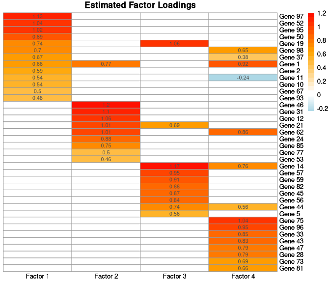

```r
factor_loading_heatmap(sim_fcs_results_regular_8$numerics_summary_need_alignment_result$reordered_summary$big_l,
                       heatmap_title = "Estimated Factor Loadings")
```

and visualize the trajectory of a specific factor for a specified person:

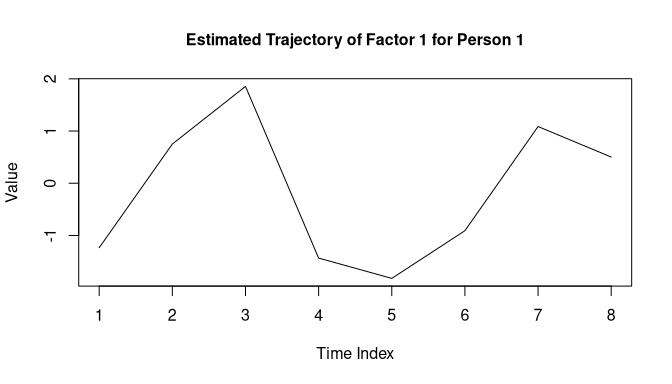

```r
# only display trajectories at training time points

factor_score_trajectory(sim_fcs_results_regular_8$numerics_summary_need_alignment_result$reordered_summary$latent_y[(1:8),,],
                        factor_index = 1,
                        person_index = 1,
                        trajectory_title = paste0("Estimated Trajectory of Factor 1 for Person 1"))
```

The model’s performance can be measured by calculating the mean absolute error of estimating true factor scores:

```r
q<- 8
k<- 4
n<- 17

a_train<-  sim_fcs_truth$a_full[(1:q)]

h3n2_data<- list()

list_temp <- vector("list", k)
for (list_index in 1:k){
  list_temp[[list_index]]<- a_train
}
h3n2_data$input<- list_temp

fcs_sigma_y_init_truth_for_train_data<- GPFDA::mgpCovMat(Data=h3n2_data, hp=sim_fcs_truth$gp_hp_truth)

# rescale truth
d_matrix<- diag(sqrt(diag(fcs_sigma_y_init_truth_for_train_data)))
d_matrix_inv<- solve(d_matrix)

fcs_real_y_rescaled<- array(0, dim = c(q,k,n))

for (person_index in 1:n){
  fcs_real_y_rescaled[,,person_index]<- matrix(d_matrix_inv%*%as.numeric(sim_fcs_truth$real_y[1:q,,person_index]),
                                               nrow = q,
                                               ncol = k)
}

# compare
mae_regular_8<-  mean(abs(sim_fcs_results_regular_8$numerics_summary_need_alignment_result$reordered_summary$latent_y[(1:q),,] - fcs_real_y_rescaled))

mae_regular_8
```

```
## [1] 0.225626
```